# Homologias, Caracteres e Mensurações

damelo@ib.usp.br

## Objetivos

- Relacionar o contexto teórico de um fenômeno de interesse às formas de mensurar seus efeitos
- Elaborar esta relação a respeito de sistemas morfológicos, seu desenvolvimento e função

## Homologias

- Relações de equivalência entre atributos em espécies distintas
  - Revelam origens evolutivas em comum
  - Vias de desenvolvimento compartilhadas
  - Relação global entre atributos

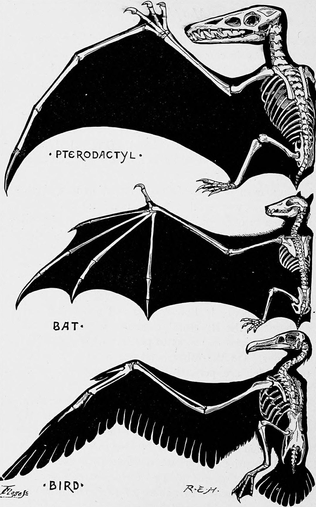

## Um exemplo mais extremo

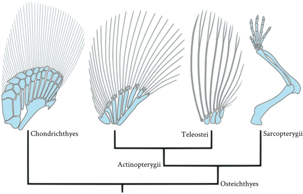

- Desenvolvimento dos elementos ósseos determinado pela expressão dos mesmos *loci* nas três linhagens
- Elementos ósseos adicionais nas linhagens derivadas regulados pelos mesmos *loci* em uma fase posterior

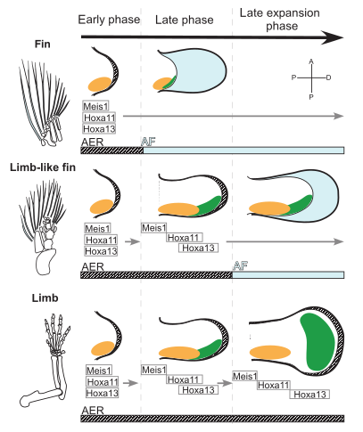

## Homologias e Mapas Genótipo-Fenótipo

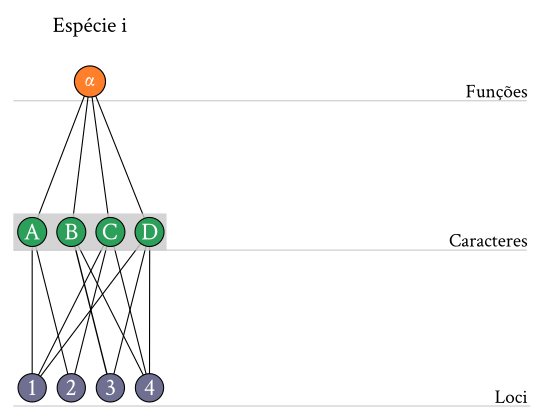

## Homologias e Mapas Genótipo-Fenótipo

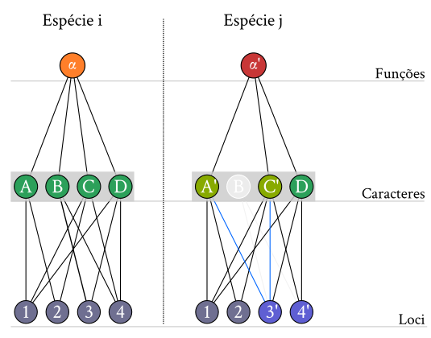

## Como reconhecer homologias?

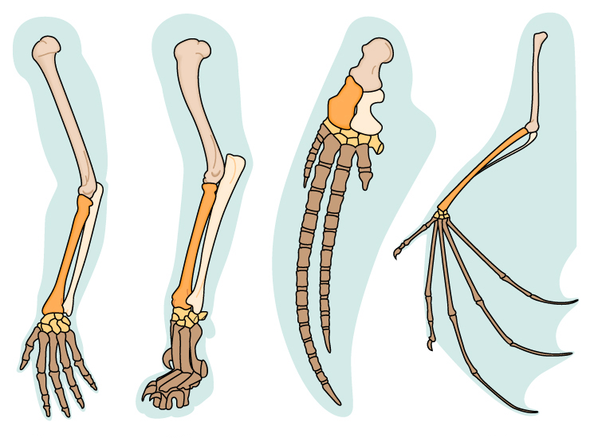

## Caráter

Conjunto de atributos *mutuamente exclusivos* identificados em um conjunto de organismos

- *Mutuamente exclusivos*: a cada organismo atribui-se apenas um estado do caráter

## Exemplo: Coloração

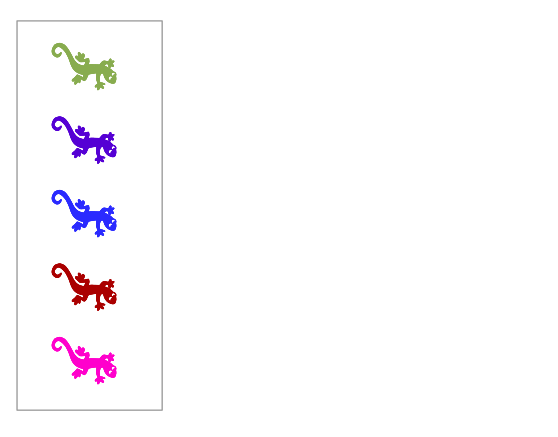

## Exemplo: Coloração

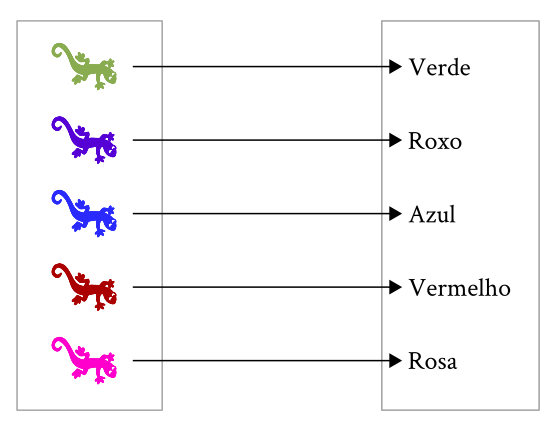

## Exemplo: Coloração

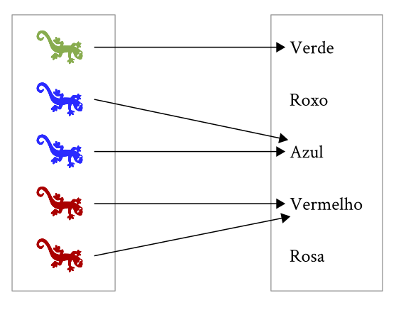

## Exemplo: Coloração

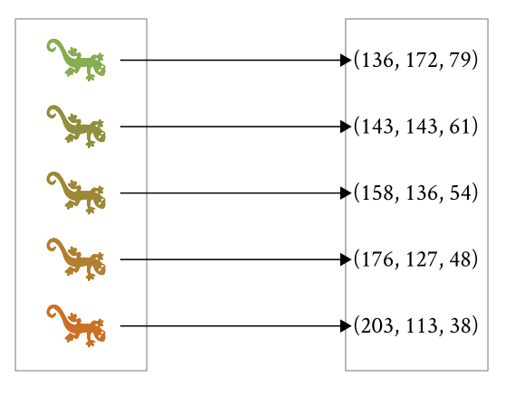

## Em princípio…

- Homologias não aparecem nesta definição de caráter
- Caracteres são divisões arbitrárias que somos capazes de reconhecer em organismos ou suas partes
- O uso de um conjunto particular de caracteres se justifica com base no contexto teórico de referência

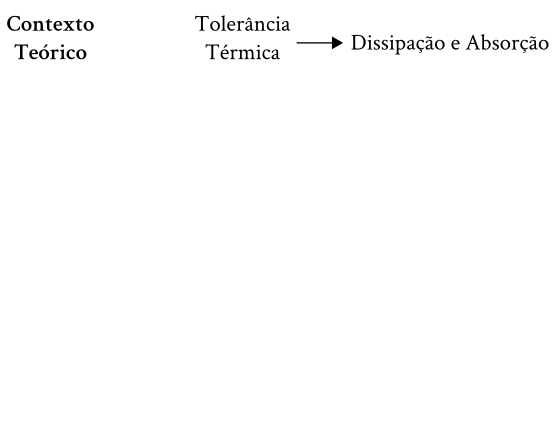

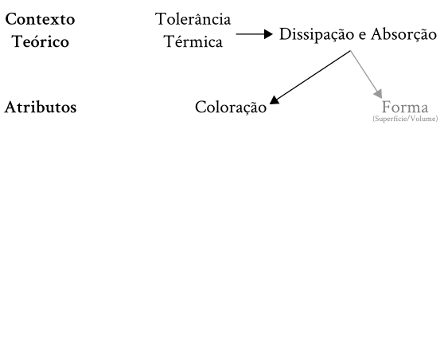

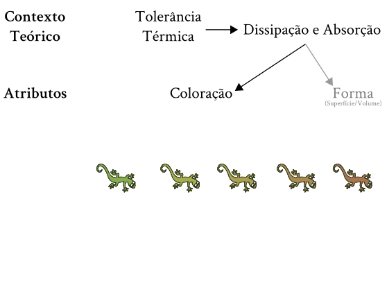

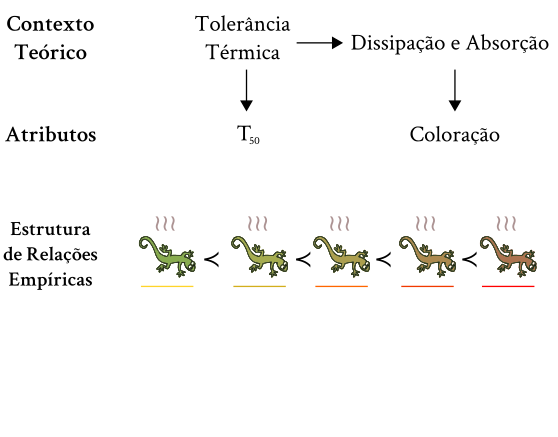

## Mensuração

- *Estrutura de relações empíricas*: objetos reais, seus atributos e o conjunto de operações sobre eles
- *Estrutura de relações numéricas*: valores/estados dos atributos e o conjunto de operações válidas entre estes valores
- **Mensuração**: Relação de equivalência entre estas estruturas

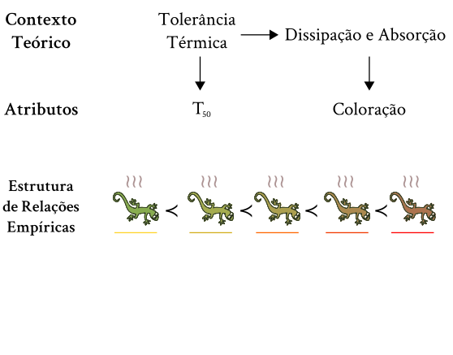

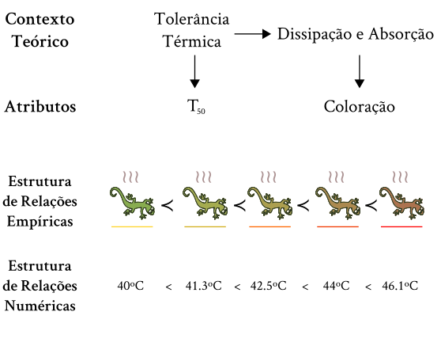

## Temperatura

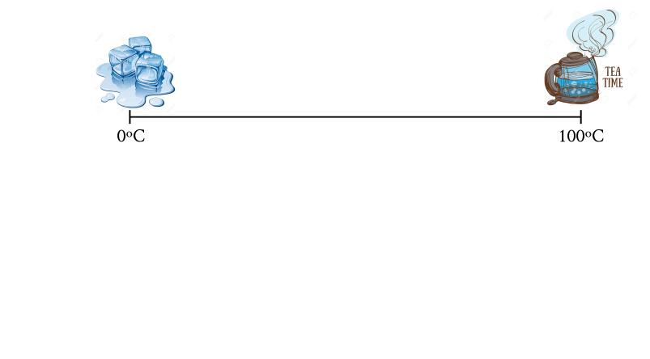

## Temperatura

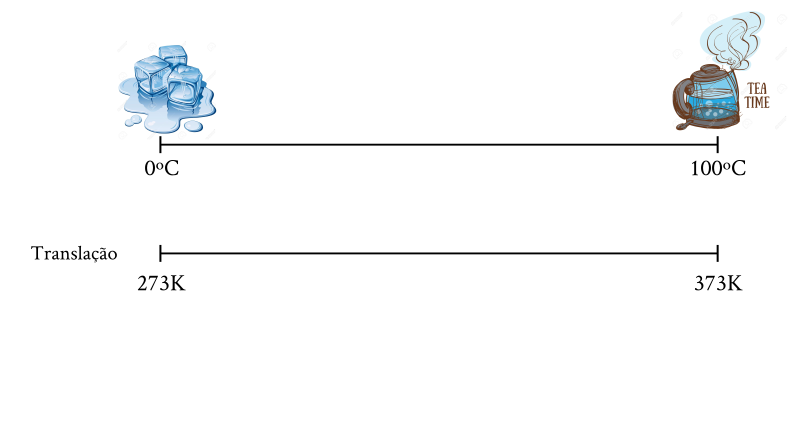

## Temperatura

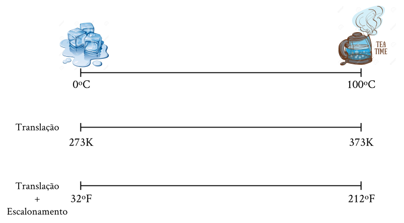

## Temperatura

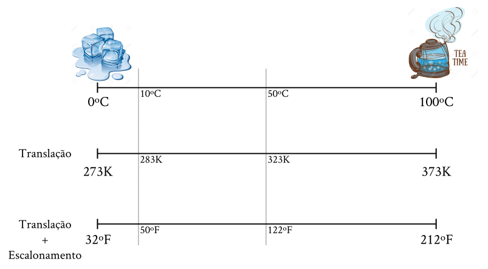

## Temperatura

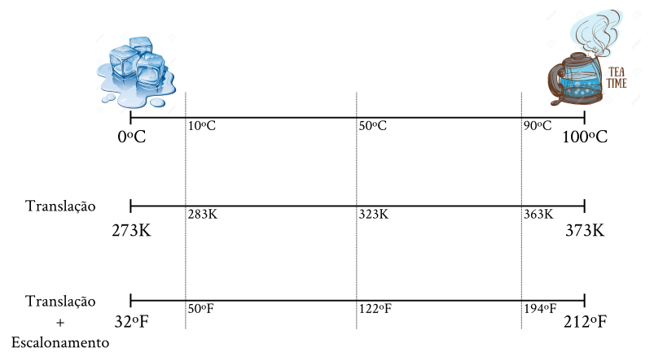

## Temperatura

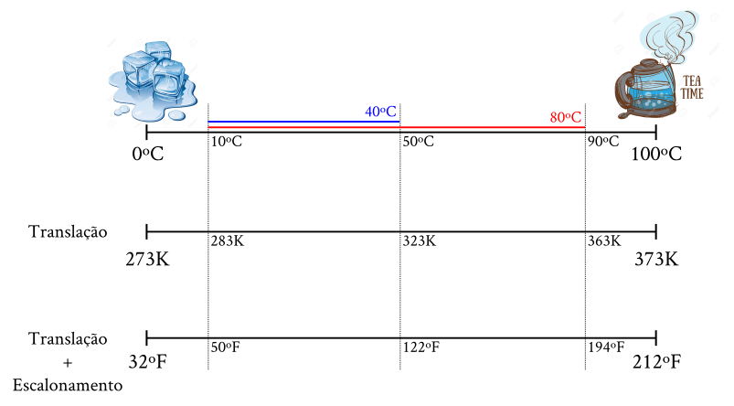

## Temperatura

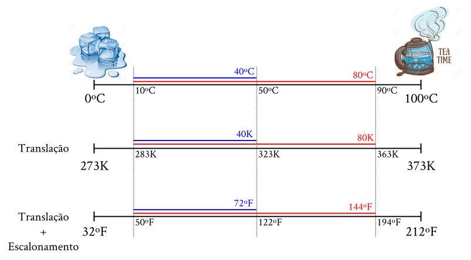

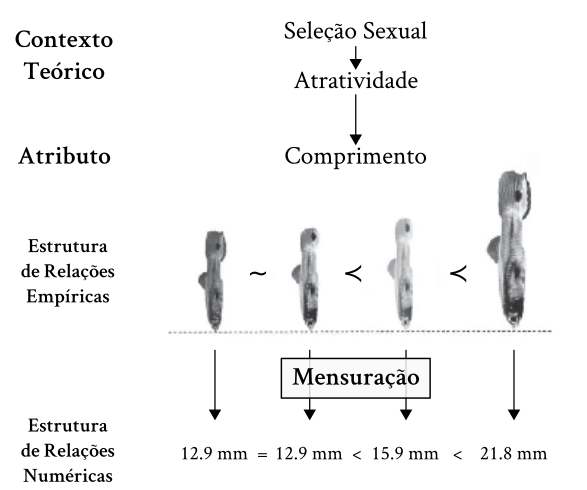

## Tamanho e Peso

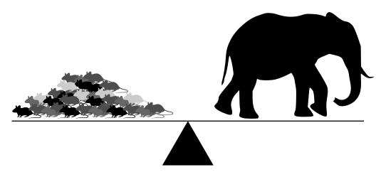

- Comparação entre objetos permite estrutura de produto nas relações numéricas
- Passível de transformação para escala log

## Medidas de referência

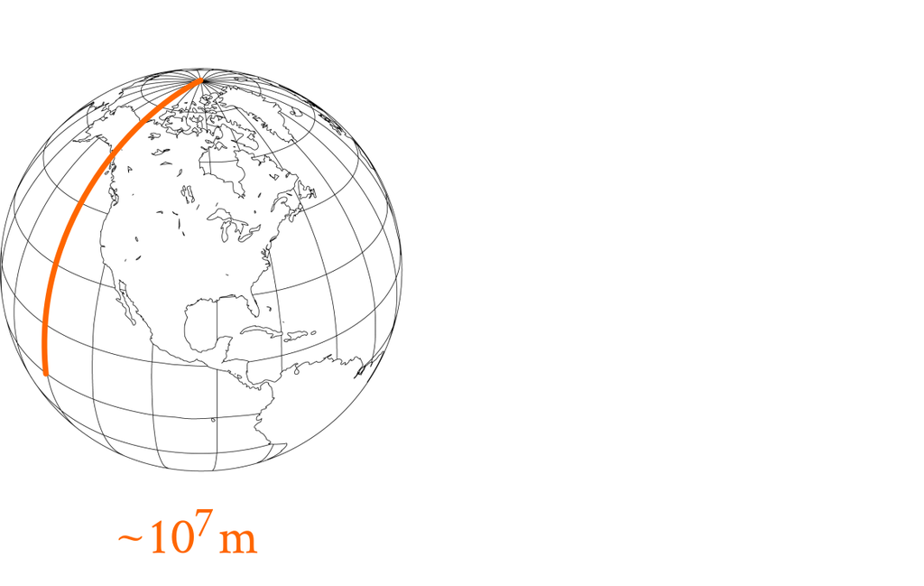

## Medidas de referência

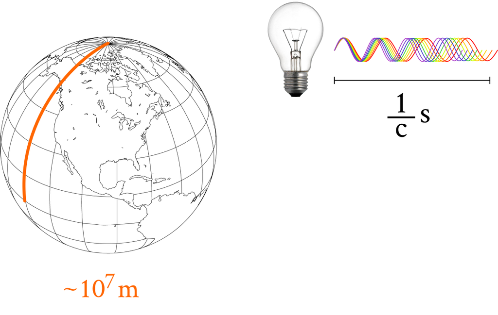

## Medidas de referência

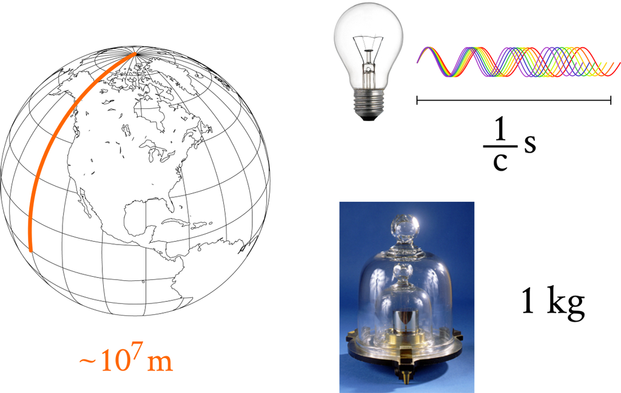

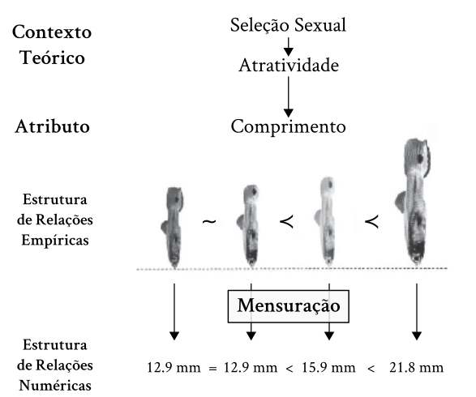

## Medidas Pragmáticas

- Como mensurar atratividade?
- Poderíamos fazer um experimento:

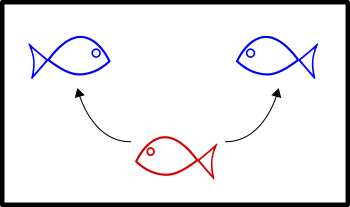